# TMA4315 Generalized linear models H2017

Module 1: INTRODUCTION

Mette Langaas, Department of Mathematical Sciences, NTNU

21.08 [PL=plenary lecture in F3], 23.08 [IL=interactive lecture in Smia]. (Version 23.08.2017)

# Aim of this module

- this course: expanding the linear regression framework
- short presentation of all course modules
- learning outcome
- practical details of the course (Blackboard)
- core concept: the exponential family of distributions
- learn about - and use - `R`, `Rstudio`, `R Markdown`, and get familiar with related topics
- explore `Munich rent` data set and the ggplot graphics (from `tidyverse libraries` from data science)
- get up to speed on R (and writing reports in R markdown) to be able to do the 3*10-points compulsory exercises by doing recommended exercises

# $\oplus$ Expanding the linear regression framework

Written in class 21.08.2017: https://www.math.ntnu.no/emner/TMA4315/2017h/M1Classnotes20170821.pdf

You know simple linear regression from TMA4240/TMA4245 (or similar introductory courses), and multiple linear regression (from TMA4267 Linear statistical models or TMA4255 Applied Statistics). We will stay with regression (for the whole course) - but make expansions in several directions.

What will not change:

- our target is *a random response* (from some statistical distribution): continuous, nominal or ordinal, we have
- *fixed covariates (or explanatory variables)* (in a design matrix): quantitative or qualitative, and
- *unknown regression parameters*.

We will consider relationships between the conditional mean of Y, $\text{E}(Y\mid {\bf x})=\mu$, and linear combinations of the covariates in *a linear predictor* $\eta_i=\beta_0+\beta_1 x_{i1}+\cdots +\beta_k x_{ik}={\bf x}_i^T {\bf \beta}$.

For most of the course we will assume observation pairs ($Y_i,{\bf x}_i$) are independent $i=1,\ldots,n$, but we will also consider clustered pairs (in Module 7: Linear mixed effects models LMM and Generalized linear mixed effects models GLMM).

# Course content

H2016: Principles of statistical modelling and inference. Likelihood theory. General theory for generalised linear models, with applications to regression models for normally distributed data, logistic regression for binary and multinomial data, Poisson regression models and log-linear models for contingency tables. Extensions of GLM-theory to, for example, models for over-dispersion and quasi-likelihood estimation.

H2017: Added linar mixed and general linear mixed models.

# The modules - in short

*Textbook:* Fahrmeir, Kneib, Lang, Marx (2013): “Regression. Models, Methods and Applications” https://link.springer.com/book/10.1007%2F978-3-642-34333-9 (free ebook for NTNU students). Tentative reading list: main parts of Chapters 2, 3 (repetition), 5, 6, 7, Appendix B.4.

The modules of this course are:

1. Introduction (the module page you are reading now) [week 34]
2. Multiple linear regression (emphasis on likelihood) [week 35-36]
3. Binary regression (binary individual and grouped response) [week 37-38]
4. Poisson and gamma regression (count, non-normal continuous) [week 39-40]
5. GLM in general and quasi likelihood (exponential family, link function) [week 41-42]
6. Multinomial GLM and contingency tables [week 43]
7. Linear mixed models (clustered data, repeated measurements) [week 44-45]
8. Generalized mixed effects models [week 46]
9. Discussion and conclusion [week 47]

## Module 2: Multiple linear regression

### Example: Exam TMA4267, V2017, Problem 2: CVD

The Framingham Heart Study is a study of the etiology (i.e. underlying causes) of cardiovascular disease (CVD), with participants from the community of Framingham in Massachusetts, USA https://www.framinghamheartstudy.org/. This dataset is subset of a teaching version of the Framingham data, used with permission from the Framingham Heart Study.

We will focus on modelling systolic blood pressure using data from $n=2600$ persons. For each person in the data set we have measurements of the following seven variables

- `SYSBP` systolic blood pressure (mmHg),
- `SEX` 1=male, 2=female,
- `AGE` age (years) at examination,
- `CURSMOKE` current cigarette smoking at examination: 0=not current smoker, 1= current smoker,
- `BMI` body mass index (kg/m$^2$),
- `TOTCHOL` serum total cholesterol (mg/dl), and
- `BPMEDS` use of anti-hypertensive medication at examination: 0=not currently using, 1=currently using.

A multiple normal linear regression model was fitted to the data set with $-\frac{1}{\sqrt{SYSBP}}$ as response and all the other variables as covariates.

The data set is here called `thisds`.

```r
modelB=lm(-1/sqrt(SYSBP)~SEX+AGE+CURSMOKE+BMI+TOTCHOL+BPMEDS,data=thisds)
summary(modelB)
```

```
##
## Call:
## lm(formula = -1/sqrt(SYSBP) ~ SEX + AGE + CURSMOKE + BMI + TOTCHOL +
##     BPMEDS, data = thisds)
##
## Residuals:
##        Min         1Q     Median         3Q        Max
## -0.0207366 -0.0039157 -0.0000304  0.0038293  0.0189747
##
## Coefficients:
##               Estimate Std. Error t value Pr(>|t|)
## (Intercept) -1.103e-01  1.383e-03 -79.745  < 2e-16 ***
## SEX         -2.989e-04  2.390e-04  -1.251 0.211176
## AGE          2.378e-04  1.434e-05  16.586  < 2e-16 ***
## CURSMOKE    -2.504e-04  2.527e-04  -0.991 0.321723
## BMI          3.087e-04  2.955e-05  10.447  < 2e-16 ***
## TOTCHOL      9.288e-06  2.602e-06   3.569 0.000365 ***
## BPMEDS       5.469e-03  3.265e-04  16.748  < 2e-16 ***
## ---
## Signif. codes:  0 '***' 0.001 '**' 0.01 '*' 0.05 '.' 0.1 ' ' 1
##
## Residual standard error: 0.005819 on 2593 degrees of freedom
## Multiple R-squared:  0.2494, Adjusted R-squared:  0.2476
## F-statistic: 143.6 on 6 and 2593 DF,  p-value: < 2.2e-16
```

**PLAN:** We will recapitulate what we have learned in TMA4267 Linear statistical models, and then focus likelihood theory, and how this can be implemented in Compulsory exercise 1.

**Textbook**: Chapter 3 (from TMA4267) and parts of Appendix B4.

## Module 3: Binary regression

How can be model a respons that is not a continuous variable? Here we look at present/absent, true/false, healthy/diseased.

## Example: Mortality of beetles

About 60 beetles were exposed to each of 8 different concentrations of CS$_2$ (data on log10-dose), and the number killed at each of the concentrations were recorded.

```r
#install.packages("investr")
library(investr)
head(beetle)
```

```
##    ldose  n  y
## 1 1.6907 59  6
## 2 1.7242 60 13
## 3 1.7552 62 18
## 4 1.7842 56 28
## 5 1.8113 63 52
## 6 1.8369 59 53
```

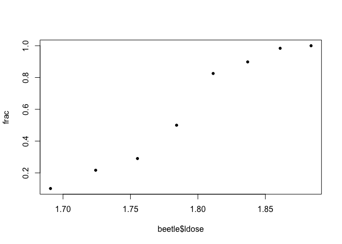

```r
frac=beetle$y/beetle$n
plot(beetle$ldose,frac,pch=20)
```

What might be the distribution of the number of dead beetles, $Y_i$ at a given dose $x_i$? Dose $x_i$ was given to $n_i$ beetles.

$$Y_i=bin(n_i,\pi_i)$$
where $\pi_i$ =probability for a beetle to die at dose $x_i$ and $n_i$= number of beetles treated with dose $x_i$. A linear model for $\pi_i$ estimated by ordinary least squares is problematic because

- $0 \le \pi_i \le 1$ can not be guaranteed by a linear expression $\beta_0+\beta_1 x_i$, and
- $\text{Var}(Y_i) =n_i \pi_i (1-\pi_i)$ is non-constant (heteroscedastic) variance.

The “usual” solution to this is *logistic regression* where the relationship between the mean of the response and the predictor is not linear, but instead
$$\ln(\frac{\pi_i}{1-\pi_i})= \beta_0+\beta_1 x_i$$
or equivalently
$$\pi_i=\frac{\exp(\beta_0+\beta_1 x_i)}{1+\exp(\beta_0+\beta_1 x_i)}$$

Then $0\le \pi_i\le 1$. We estimate the model by Maximum Likelihood (ML), while taking into account that the responses are binomially distributed.

```r
fit=glm(cbind(beetle$y,beetle$n-beetle$y)~ldose,data=beetle,family=binomial)
summary(fit)
```

```
##
## Call:
## glm(formula = cbind(beetle$y, beetle$n - beetle$y) ~ ldose, family = binomial,
##     data = beetle)
##
## Deviance Residuals:
##     Min       1Q   Median       3Q      Max
## -1.5941  -0.3944   0.8329   1.2592   1.5940
##
## Coefficients:
##             Estimate Std. Error z value Pr(>|z|)
## (Intercept)  -60.717      5.181  -11.72   <2e-16 ***
## ldose         34.270      2.912   11.77   <2e-16 ***
## ---
## Signif. codes:  0 '***' 0.001 '**' 0.01 '*' 0.05 '.' 0.1 ' ' 1
##
## (Dispersion parameter for binomial family taken to be 1)
##
##     Null deviance: 284.202  on 7  degrees of freedom
## Residual deviance:  11.232  on 6  degrees of freedom
## AIC: 41.43
##
## Number of Fisher Scoring iterations: 4
```

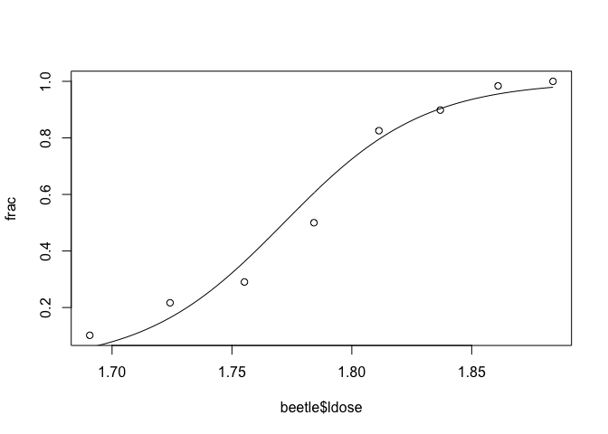

```r
thisrange=range(beetle$ldose)
xs=seq(thisrange[1],thisrange[2],length=100)
predicted=predict(fit,newdata=data.frame(ldose=xs),type="response")
plot(beetle$ldose,frac)
lines(xs,predicted)
```

**PLAN:** In this module we will study the binary regression, work on parameter estimation and interpretation of parameter estimates using odds, work with both individual and grouped data, test linear hypotheses, look at criteria for model fit and model choice, and discuss overdispersion.

**Textbook:** 2.3 and 5.1.

## Module 4: Poisson and gamma regression

Count data - the number of times and event occurs - is common. In one famous study British doctore were in 1951 sent a questionnaire about whether they smoked tobacco - and later information about their death were collected. Questions that were asked were: Is the death rate higher for smokers than for non-smokers? If so, by how much? And, how is this related to age?

```r
library(boot)
#n=person-year, ns=smoker-years,
#age=midpoint 10 year age group,
#y=number of deaths due to cad, smoke=smoking status
head(breslow)
```

```
##   age smoke     n  y    ns
## 1  40     0 18790  2     0
## 2  50     0 10673 12     0
## 3  60     0  5710 28     0
## 4  70     0  2585 28     0
## 5  80     0  1462 31     0
## 6  40     1 52407 32 52407
```

To investigate this we will look at different ways of relating the expected number of deaths and the number of doctors at risk in the observation period for each smoke and age group. We will do this by assuming a Poission distribution for the number of deaths, and linking this to a linear predictor.

When we work with continuous data - like life times, costs and claim sized - these may not be negative, and the their distribution often follow a right skewed distribution. We will look at effect a one of more covariates that may work multiplicative on the response and see how we may fit that using gamma regression on the log scale of the response.

**Textbook:** 5.2 and 5.3

## Module 5: GLM in general and quasi likelihood

We will see that normal, binary, Poisson and gamma regression all have the same underlying features:

1. The mean of the response, $\mu=\text{E}(Y)$, is connected to the linear predictor $\eta={\bf x}^T \beta$ by a link function: $\eta=g(\mu)$ or, alternatively, by a response function $\mu=h(\eta)$ - where $g=h^{-1}$ (inverse functions).
2. The distribution of the response can be written as a univariate exponential family (we work with that in this first module).

This leads to a unified framework, and maximum likelihood estimation can be written on a generalized form for all the GLMs. In addition we can present statistical inference and asymptotic properties of estimators on a common form. Finally, we may expand this to quasi-likelihood models by just specifying mean and variance (not distribution) and solve using generalized estimation equations.

This part is rather mathematical - but is built on the findings of modules 1-4.

**Textbook:** 5.4 and 5.5

Compulsory exercise 2 will cover modules 3-5.

## Module 6: Multinomial GLM and contingency tables

Here our response variable has more than two categories, and these categories can either be unordered or ordered. Examples of categorical responses include (unordered) data in infection (no, or socalled type I or type II) after Caesarian delivery, or (ordered) dat a on degree of defoliation of trees (nine ordered categories).

We will use the multinomial distribution as the distribution for the response, and work mainly with grouped data - that often can be presented in a contingency table.

```r
ds=read.table("https://www.math.ntnu.no/emner/TMA4315/2017h/data/caesarian.raw",header=TRUE)
head(ds)
```

```
##    n infbin RISK NPLAN ANTIB Y
## 1  0      1    1     0     1 1
## 2  1      1    1     0     1 2
## 3 17      0    1     0     1 3
## 4  0      1    0     0     1 1
## 5  0      1    0     0     1 2
## 6  2      0    0     0     1 3
```

For unordered categories (like the Caesarian delivery data) we will use many logistic regressions - each between one category and a chosen reference category. For ordered categories (like the defoliation of trees) we will use a cumulative model, also called a proportional odds model.

If time permits we will also look briefly at exact and asymptotic inference (Fishers exact test and Pearsons Chisquare test) for contingency tables (unordered categories), which is closely related to the GLM-presentation.

**Textbook:** Chapter 6, and possibly extra materiale on the Fisher and Chi-square test (if time permits).

## Module 7: Linear mixed effects models

In a study on the effect of sleep deprivation the average reaction time per day were measured. On day 0 the subjects had their normal amount of sleep. Starting that night they were restricted to 3 hours of sleep per night. The observations represent the average reaction time on a series of tests given each day to each subject. This was measured for 18 subjects for 10 days (days 0-9).

```r
library(lme4)
```

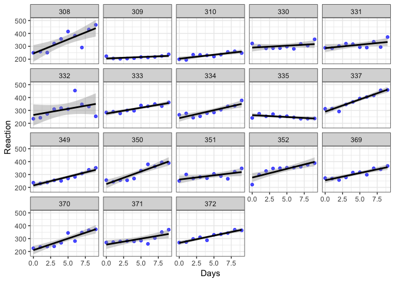

```r
library(ggplot2) # see more on ggplot later in this module
gg <- ggplot(sleepstudy, aes(x = Days, y = Reaction))
gg <- gg + geom_point(color = "blue", alpha = 0.7)
gg <- gg + geom_smooth(method = "lm", color = "black")
gg <- gg + theme_bw()
gg <- gg + facet_wrap(~Subject)
gg
```

As a first model we may assume that there is a common intercept and slope for the population - called fixed effects, but allow for random deviations for the intercept and slope for each individual. In linear mixed effects models we assume that the random intercepts and slopes are drawn from normal distributions and estimate the variance in these distribution. Such a model will make observations correlated within subjects.

```r
fm1 <- lmer(Reaction ~ Days + (Days | Subject), sleepstudy)
summary(fm1)
```

```
## Linear mixed model fit by REML ['lmerMod']
## Formula: Reaction ~ Days + (Days | Subject)
##    Data: sleepstudy
##
## REML criterion at convergence: 1743.6
##
## Scaled residuals:
##     Min      1Q  Median      3Q     Max
## -3.9536 -0.4634  0.0231  0.4634  5.1793
##
## Random effects:
##  Groups   Name        Variance Std.Dev. Corr
##  Subject  (Intercept) 612.09   24.740
##           Days         35.07    5.922   0.07
##  Residual             654.94   25.592
## Number of obs: 180, groups:  Subject, 18
##
## Fixed effects:
##             Estimate Std. Error t value
## (Intercept)  251.405      6.825   36.84
## Days          10.467      1.546    6.77
##
## Correlation of Fixed Effects:
##      (Intr)
## Days -0.138
```

Here the population fixed effects estimates are an intercept of 251.4 ms and a slope of 10.47 ms/day. The random effects for the intercept and the slope have estimated standard deviations 24.74 ms and 5.92 ms/day.

In this module we will look at different models for clustered (schools, families) and repeated measurement (e.g. over time) using regression with fixed and random effects.

**Textbook:** 2.4, 7.1, 7.3

## Module 8: Generalized linear mixed effects models

We generalize our model in Module 7 - on normal responses - to binary responses.

**Textbook:** 7.2, 7.5, 7.7

Compulsory exercise 3 will cover modules 6-8.

# Common - for all modules

1. Model specification: an equation linking the response and the explanatory variables, and a probability distribution for the response.
2. Estimation of the parameters in the model
3. Checking the adequacy of the model, how well it fits the data.
4. Inference: confidence intervals, hypothesis tests, interpretation of results.

Both theoretic derivations and practical analysis in R will be emphasized.

# Learning outcome

(new in H2017 in italic)

**Knowledge**.

The student can assess whether a generalised linear model can be used in a given situation and can further carry out and evaluate such a statistical analysis. The student has substantial knowledge of generalised linear models and associated inference and evaluation methods. This includes regression models for Gaussian distributed data, logistic regression for binary and multinomial data, Poisson regression and log-linear models for contingency tables.

*The student has theoretical knowledge about linear mixed models and generelized linear mixed effects models, and associated inference and evaluation of the models. Main emphasis is on Gaussian and binomial data.*

**Skills**.

The student can assess whether a generalised linear model *or a generalized linear mixed model* can be used in a given situation, and can further carry out and evaluate such a statistical analysis.

# Practical details - go to Blackboard

https://ntnu.blackboard.com/webapps/blackboard/execute/modulepage/view?course_id=_7293_1&cmp_tab_id=_23293_1&mode=view or https://ntnu.blackboard.com/webapps/login?action=guest_login&new_loc=/webapps/blackboard/execute/courseMain?course_id=_7293_1 (guest access).

# Teaching philosophy in this course

**The modules:**

- divide into modular units with specific focus
- smaller units (time and topic) facilitates learning?

**The plenary lectures:**

- for each module we start with a plenary lecture to introduce the aims,
- then we move to notation, and
- use real data to examplify what to learn, why this is useful and what this is used in society
- theory is then presented, discussed and
- mixed with use of R and data analysis.

The plenary lectures is rather passive in nature - for the students - and held in classical auditorium (F3). They provide the first step into the new module

**The interactive lectures (IL):**

has focus on student activity and understanding though discussing with fellow students and with the lecturer/TA - in groups.

Plan for IL - we loop through 1-5 several times each IL:

1. Lecturer gives a *short* introduction to current state, and present a problem.
2. Students work together in groups on problem.
3. The problem is presented on the digital screen, and the students discuss by interacting around the screen and often by producing R code and interpreting analysis output - all presented on the digital screen. One student may act as the “teacher”.
4. If the problem is of a theoretical flavour, or drawing is needed - the students work on the whiteboards next to the digital screen.
5. Lecturer summarizes solutions to the problem with input from the student groups.

**The compulsory exercises:**

has mainly focus on programming and interpretation - with some theory - and can be worked on in small groups. Will be a test of accuired understanding, and will constitute 30% of the final evaluation.

# $\oplus$ Core concept in course: Exponential family of distributions

In this course we will look at models where the distribution of the response variable, $y_i$, can be written in the form of a *univariate exponential family*
$$f(y_i\mid \theta_i)=\exp \left( \frac{y_i \theta_i-b(\theta_i)}{\phi_i}\cdot w_i + c(y_i, \phi_i, w_i) \right)$$
where

- $\theta_i$ is called the canonical parameter and is a parameter of interest
- $\phi_i$ is called a nuisance parameter (and is not of interest to us=therefore a nuisance (plage))
- $w_i$ is a weight function, in most cases $w_i=1$
- b and c are known functions.

It can be shown that $\text{E}(Y_i)=b'(\theta_i)$ and $\text{Var}(Y_i)=b''(\theta_i)\cdot \frac{\phi_i}{w}$.

Remark: slightly different versions of writing the exponential family exists, but we will use this version in our course (a different version might be used in TMA4295, but the basic findings are the same).

## $\odot$ Theoretical questions

To make the notation easier for these tasks, we omit the $i$ subscript.

1. What process can produce a $Y$ that is binomially distributed? Write down the probability mass function, f(x). Is the binomial distribution an the exponential family? Identify $b$ and $c$ and show the connection with the mean and variance of $Y$.

NB: you may first use $n=1$ in the binomial (which then is called Bernoulli) - since that is much easier than a general $n$.

Hint: https://wiki.math.ntnu.no/tma4245/tema/begreper/discrete and nearly the same parameterization for showing the binomial is member of exponential https://www.youtube.com/watch?v=7mNrsFr7P_A.

2. What about the Poisson distribution? (requrements, f(x) and member?)

Hint: https://wiki.math.ntnu.no/tma4245/tema/begreper/discrete and first part of [Sannsynlighetsmaksimering](https://mediasite.ntnu.no/Mediasite/Play/db9c6fbc45bf48abb8a4dd00ff146e081d?catalog=0fce6173-7a98-4db7-84b7-50cba3a3a341)

3. Then, what about the (univariate) normal? (requirements, probability density function f(x) and member?)
4. Finally, the gamma distribution? (requirements, pdf f(x) and member?)

Hint: https://wiki.math.ntnu.no/tma4245/tema/begreper/continuous

See also table on page 303 in the textbook. Mettes solution: https://www.math.ntnu.no/emner/TMA4315/2017h/Module1ExponentialFamily.pdf

# $\odot$ R, Rstudio, CRAN and GitHub - and R Markdown

What is R? https://www.r-project.org/about.html

What is Rstudio? https://www.rstudio.com/products/rstudio/

What is an R package? http://r-pkgs.had.co.nz (We will make an R package in the exercise part of this course.)

What is CRAN? https://cran.uib.no/

What is GitHub and Bitbucket? Do we need GitHub or Bitbucket in our course? https://www.youtube.com/watch?v=w3jLJU7DT5E and https://techcrunch.com/2012/07/14/what-exactly-is-github-anyway/

What is R Markdown? http://r4ds.had.co.nz/r-markdown.html

What is `knitr`? https://yihui.name/knitr/

# $\odot$ Explore R Markdown in Rstudio

The module pages (you are reading the Module 1 page now), are written using R Markdown. To work with the module pages you either copy-paste snippets of R code from the module page over in your editor window in Rstudio, or copy the Rmd-version of the module page (1Intro.Rmd) into your Rstudio editor window (then you can edit directly in Rmarkdown document - to make it into your personal copy).

If you choose the latter: To compile the R code we use `knitr` (termed “knit”) to produce a html-page you press “knit” in menu of the editor window, but first you need to install libraries: `rmarkdown` and `devtools` (from CRAN) and `prettydoc` (from GitHub). (I have commented out this in the code below, you need to run the install.packages if you have not done that before.)

```r
#install.packages("rmarkdown")
library(rmarkdown)
#install.packages("devtools")
library(devtools)
#install_github("yixuan/prettydoc")
library(prettydoc)
```

If you want to learn more about the R Markdown (that you may use for the compulsory exercises) this is a good read:

- http://r4ds.had.co.nz/r-markdown.html (Chapter 27: R Markdown from the “R for Data Science” book), and
- the Rstudio cheat sheet on R Markdown is here: https://www.rstudio.com/wp-content/uploads/2016/03/rmarkdown-cheatsheet-2.0.pdf.

Then you see that you can make a pdf-file in addition to a html-file (for your reports you may choose either).

# Not use R Markdown, but only R code?

If you only want to extract the R code from a R Markdown file you may do that using the function `purl` from library `knitr`. To produce a file “1Intro.R” from this “1Intro.Rmd” file:

```r
require(knitr)
purl("https://www.math.ntnu.no/emner/TMA4315/2017h/1Intro.Rmd")
```

The file will then be saved in your working directory, that you see with `getwd()`.

# Libraries needed to work with this module in R

And to work with either the 1Intro.R or 1Intro.Rmd file you will have to first install the following libraries:

```r
install.packages("rmarkdown")
install.packages("devtools")
#library(devtools) # before installing from github
#install_github("yixuan/prettydoc")
install.packages("prettydoc")
install.packages("gamlss.data")
install.packages("tidyverse")
install.packages("ggpubr")
install.packages("investr")
install.packages("lme4")
```

# $\odot$ The Munic Rent Index Data set

We will use this data set when working with multiple linear regression (next module), so this is a good way to start to know the data set and the ggplot functions, which can be installed together with a suite of useful libraries from `tidyverse`.

```r
#install.packages("gamlss.data")
#install.packages("tidyverse")
library(gamlss.data)

#library(tidyverse) #automatically loads ggplot2
```

Get to know the `rent` data.

```r
ds=rent99
colnames(ds)
```

```
## [1] "rent"     "rentsqm"  "area"     "yearc"    "location" "bath"
## [7] "kitchen"  "cheating" "district"
```

```r
dim(ds)
```

```
## [1] 3082    9
```

```r
summary(ds)
```

```
##       rent            rentsqm             area            yearc
##  Min.   :  40.51   Min.   : 0.4158   Min.   : 20.00   Min.   :1918
##  1st Qu.: 322.03   1st Qu.: 5.2610   1st Qu.: 51.00   1st Qu.:1939
##  Median : 426.97   Median : 6.9802   Median : 65.00   Median :1959
##  Mean   : 459.44   Mean   : 7.1113   Mean   : 67.37   Mean   :1956
##  3rd Qu.: 559.36   3rd Qu.: 8.8408   3rd Qu.: 81.00   3rd Qu.:1972
##  Max.   :1843.38   Max.   :17.7216   Max.   :160.00   Max.   :1997
##  location bath     kitchen  cheating    district
##  1:1794   0:2891   0:2951   0: 321   Min.   : 113
##  2:1210   1: 191   1: 131   1:2761   1st Qu.: 561
##  3:  78                              Median :1025
##                                      Mean   :1170
##                                      3rd Qu.:1714
##                                      Max.   :2529
```

Then, head for plotting with `ggplot` but first take a quick look at the `ggplot2` library:

- Grolemund and Hadwick (2017): “R for Data Science”, Chapter 3: Visualisation: http://r4ds.had.co.nz/data-visualisation.html

Before you continue you should have read the start of the Visualisation chapter that explains the ggplot grammar. Yes, you start with creating the coordinate system with `ggplot` and then add layers. What does the following words mean: mapping, aesthetic, geom function mean in the `ggplot` setting?

- The Rstudio cheat sheet on ggplot2 is here: https://www.rstudio.com/wp-content/uploads/2016/11/ggplot2-cheatsheet-2.1.pdf

First, look at plotting `rentsqm` for different values of `location` - with panels of scatter plots and with boxplots

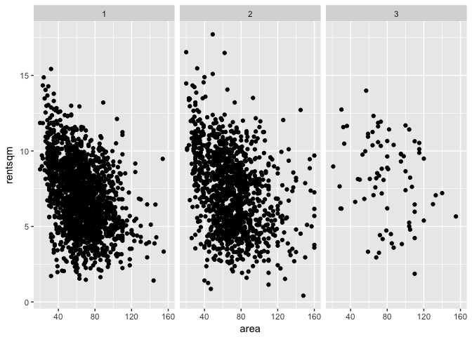

```r
ggplot(data=ds)+
  geom_point(mapping=aes(area,rentsqm))+
  facet_wrap(~location,nrow=1)
```

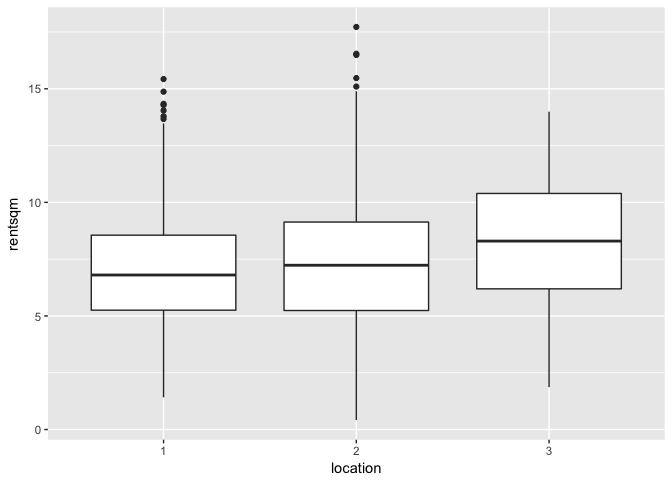

```r
ggplot(data = ds, mapping = aes(x = location, y = rentsqm)) +
  geom_boxplot()
```

So, location matters.

But, should we use `rent` or `rentsqm` as response?

```r
#install.packages("ggpubr")
require(ggpubr)
```

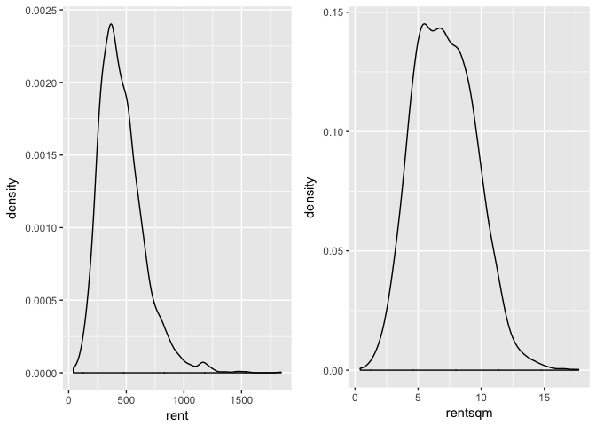

```r
plot1 <- ggplot(data=ds) +
  geom_density(mapping=aes(rent),kernel="gaussian")
plot2 <- ggplot(data=ds) +
  geom_density(mapping=aes(rentsqm),kernel="gaussian")
ggarrange(plot1, plot2, ncol=2)
```

So, which response will we use? And, what if we would include `area` as covariate? I have plotted two plots together below, more on mixing graphs on the same page (we need ggprbr, gridExtra and cowplot packages) https://www.r-bloggers.com/ggplot2-easy-way-to-mix-multiple-graphs-on-the-same-page/

Relationship between `rent` or `rentsqm` and `area`

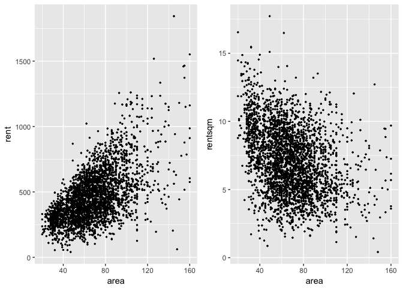

```r
plot1 <- ggplot(data=ds,aes(area,rent))+
  geom_point(mapping=aes(area,rent),size=0.5)
plot2 <- ggplot(data=ds)+
  geom_point(mapping=aes(area,rentsqm),size=0.5)
ggarrange(plot1, plot2, ncol=2)
```

So, if we include area as a covariate, we may look at residuals when using `rent` or `rentsqm`. More about diagnostic plots in Module 2 - but - which plot below looks more random?

```r
lm.rent=lm(rent~area,data=ds)
summary(lm.rent)
```

```
##
## Call:
## lm(formula = rent ~ area, data = ds)
##
## Residuals:
##     Min      1Q  Median      3Q     Max
## -786.63 -104.88   -5.69   95.93 1009.68
##
## Coefficients:
##             Estimate Std. Error t value Pr(>|t|)
## (Intercept) 134.5922     8.6135   15.63   <2e-16 ***
## area          4.8215     0.1206   39.98   <2e-16 ***
## ---
## Signif. codes:  0 '***' 0.001 '**' 0.01 '*' 0.05 '.' 0.1 ' ' 1
##
## Residual standard error: 158.8 on 3080 degrees of freedom
## Multiple R-squared:  0.3417, Adjusted R-squared:  0.3415
## F-statistic:  1599 on 1 and 3080 DF,  p-value: < 2.2e-16
```

```r
lm.rentsqm=lm(rentsqm~area,data=ds)
summary(lm.rentsqm)
```

```
##
## Call:
## lm(formula = rentsqm ~ area, data = ds)
##
## Residuals:
##     Min      1Q  Median      3Q     Max
## -6.9622 -1.5737 -0.1102  1.5861  9.9674
##
## Coefficients:
##             Estimate Std. Error t value Pr(>|t|)
## (Intercept)  9.46883    0.12426   76.20   <2e-16 ***
## area        -0.03499    0.00174  -20.11   <2e-16 ***
## ---
## Signif. codes:  0 '***' 0.001 '**' 0.01 '*' 0.05 '.' 0.1 ' ' 1
##
## Residual standard error: 2.291 on 3080 degrees of freedom
## Multiple R-squared:  0.1161, Adjusted R-squared:  0.1158
## F-statistic: 404.5 on 1 and 3080 DF,  p-value: < 2.2e-16
```

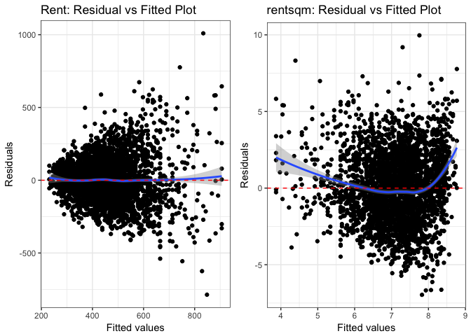

```r
p1<-ggplot(lm.rent, aes(.fitted, .resid))+geom_point()
p1<-p1+stat_smooth(method="loess")+geom_hline(yintercept=0, col="red", linetype="dashed")
p1<-p1+xlab("Fitted values")+ylab("Residuals")
p1<-p1+ggtitle("Rent: Residual vs Fitted Plot")+theme_bw()
p2<-ggplot(lm.rentsqm, aes(.fitted, .resid))+geom_point()
p2<-p2+stat_smooth(method="loess")+geom_hline(yintercept=0, col="red", linetype="dashed")
p2<-p2+xlab("Fitted values")+ylab("Residuals")
p2<-p2+ggtitle("rentsqm: Residual vs Fitted Plot")+theme_bw()
ggarrange(p1, p2, ncol=2)
```

# $\odot$ Further reading

- Grolemund and Hadwick (2017): “R for Data Science”, http://r4ds.had.co.nz
- Hadwick (2009): “ggplot2: Elegant graphics for data analysis” textbook: https://link.springer.com/book/10.1007%2F978-0-387-98141-3
- R-bloggers: https://https://www.r-bloggers.com/ is a good place to look for tutorials.

# $\odot$ Recommended exercises

Aim: get up to speed on coding in R and use of R-markdown.

1. Choose one of the distributions you studied earlier (binomial, Poisson, normal or gamma), and write a R-markdown document answering the questions on requirements, f(x), f(x) as exponential family and mean and variance. Also add R-code to plot f(x) and F(x) for a given set of parameters - and add the mean as a vertical line - using the ggplot library. Submit your Rmd document to the lecturer (email) - so it can be added to this module, or make your own github repository and email the link to your repo to be added to this module page.
2. If you want to see more of the powers of ggplot, combined with a nice story: <https://www.andrewheiss.com/blog/2017/08/10/exploring-minards-1812-plot-with-ggplot2/